# BANA610Project

```python
import numpy as np
import matplotlib.pyplot as plt
import pandas as pd
import seaborn as sns
import statistics as st
from matplotlib import image as mpimg
```

```python
df_wag = pd.read_csv('wages_by_education.csv')
df_wag.head()
```

|  | year | less_than_hs | high_school | some_college | bachelors_degree | advanced_degree | men_less_than_hs | men_high_school | men_some_college | men_bachelors_degree | ... | black_women_less_than_hs | black_women_high_school | black_women_some_college | black_women_bachelors_degree | black_women_advanced_degree | hispanic_women_less_than_hs | hispanic_women_high_school | hispanic_women_some_college | hispanic_women_bachelors_degree | hispanic_women_advanced_degree |
| --- | --- | --- | --- | --- | --- | --- | --- | --- | --- | --- | --- | --- | --- | --- | --- | --- | --- | --- | --- | --- | --- |
| 0 | 2022 | 16.52 | 21.94 | 24.81 | 41.60 | 53.22 | 17.99 | 24.08 | 27.96 | 49.01 | ... | 13.89 | 17.83 | 20.36 | 29.94 | 39.41 | 14.74 | 18.18 | 20.64 | 31.13 | 40.64 |
| 1 | 2021 | 16.74 | 22.28 | 24.92 | 41.32 | 53.45 | 18.34 | 24.36 | 27.96 | 47.83 | ... | 13.73 | 18.30 | 20.18 | 29.35 | 40.07 | 14.97 | 18.34 | 21.14 | 31.25 | 42.47 |
| 2 | 2020 | 17.02 | 22.70 | 25.44 | 41.65 | 53.74 | 18.76 | 25.09 | 28.55 | 48.15 | ... | 13.66 | 17.93 | 20.31 | 31.38 | 42.44 | 14.58 | 18.50 | 20.69 | 31.55 | 44.15 |
| 3 | 2019 | 16.11 | 21.64 | 24.00 | 39.61 | 51.57 | 17.55 | 23.99 | 26.99 | 45.74 | ... | 13.30 | 17.18 | 19.17 | 30.31 | 40.42 | 14.50 | 17.71 | 19.69 | 30.18 | 42.30 |
| 4 | 2018 | 15.94 | 21.50 | 23.70 | 38.87 | 51.03 | 17.70 | 23.72 | 26.61 | 44.97 | ... | 12.48 | 16.81 | 18.57 | 30.85 | 39.64 | 13.47 | 17.28 | 19.29 | 29.47 | 39.35 |

5 rows × 61 columns

```python
df_sal = pd.read_csv('salaries.csv')
df_sal.head()
```

|  | work_year | experience_level | employment_type | job_title | salary | salary_currency | salary_in_usd | employee_residence | remote_ratio | company_location | company_size |
| --- | --- | --- | --- | --- | --- | --- | --- | --- | --- | --- | --- |
| 0 | 2023 | EX | FT | Prompt Engineer | 240000 | CHF | 262797 | CH | 50 | CH | L |
| 1 | 2023 | MI | FT | Research Analyst | 100000 | USD | 100000 | US | 0 | US | S |
| 2 | 2023 | EX | FT | Data Engineer | 185000 | USD | 185000 | US | 0 | US | M |
| 3 | 2023 | EX | FT | Data Engineer | 125000 | USD | 125000 | US | 0 | US | M |
| 4 | 2023 | EN | FT | Data Management Analyst | 60000 | USD | 60000 | US | 100 | US | M |

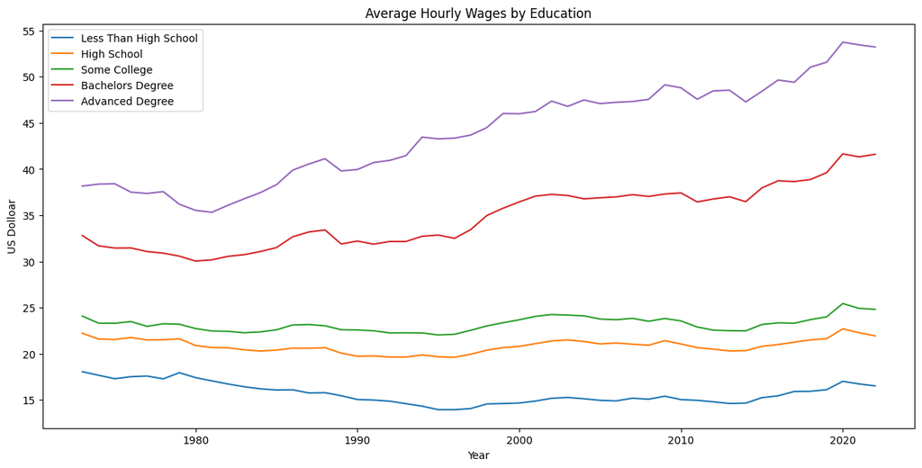

```python
plt.figure(figsize=(15, 7))
plt.plot(df_wag.year, df_wag.less_than_hs, label='Less Than High School')
plt.plot(df_wag.year, df_wag.high_school, label='High School')
plt.plot(df_wag.year, df_wag.some_college, label='Some College')
plt.plot(df_wag.year, df_wag.bachelors_degree, label='Bachelors Degree')
plt.plot(df_wag.year, df_wag.advanced_degree, label='Advanced Degree')
plt.title('Average Hourly Wages by Education')
plt.xlabel('Year')
plt.ylabel('US Dolloar')
plt.legend(loc=2)
plt.show()
```

In the last 3 decades there had been always a relationdhip between the education level and hourly wages in the US, and the salary gap between higher educationl level and the loweest level has become wider during recent years.

```python
df_wag['men']=(df_wag['men_less_than_hs']+df_wag['men_high_school']+df_wag['men_some_college']+df_wag['men_bachelors_degree']+df_wag['men_advanced_degree'])/5
df_wag['women']=(df_wag['women_less_than_hs']+df_wag['women_high_school']+df_wag['women_some_college']+df_wag['women_bachelors_degree']+df_wag['women_advanced_degree'])/5
```

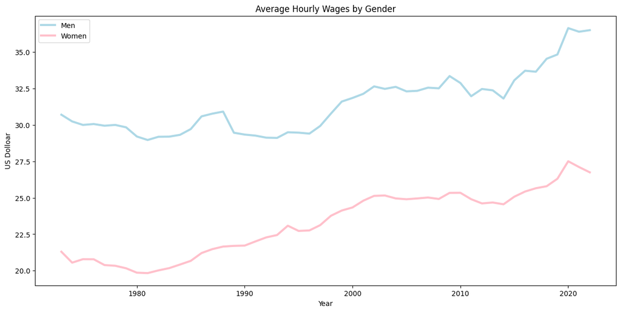

```python
plt.figure(figsize=(15, 7))
plt.plot(df_wag.year, df_wag.men, label='Men', color='lightblue', linewidth=3)
plt.plot(df_wag.year, df_wag.women, label='Women', color='pink', linewidth=3)
plt.title('Average Hourly Wages by Gender')
plt.xlabel('Year')
plt.ylabel('US Dolloar')
plt.legend(loc=2)
plt.show()
```

Men had consistently recieved higher wages in comparison to women through the last 3 decades.

```python
df_wag['all']=(df_wag['men']+df_wag['women'])/2
```

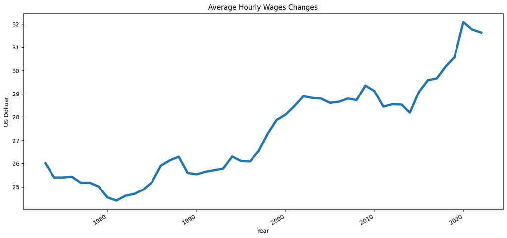

```python
plt.figure(figsize=(15, 7))
sns.lineplot(data=df_wag, x='year', y='all', linewidth=4)
plt.gcf().autofmt_xdate()
plt.title('Average Hourly Wages Changes')
plt.xlabel('Year')
plt.ylabel('US Dolloar')
plt.show()
```

```python
df_wag['white']=(df_wag['white_less_than_hs']+df_wag['white_high_school']+df_wag['white_some_college']+df_wag['white_bachelors_degree']+df_wag['white_advanced_degree'])/5
df_wag['black']=(df_wag['black_less_than_hs']+df_wag['black_high_school']+df_wag['black_some_college']+df_wag['black_bachelors_degree']+df_wag['black_advanced_degree'])/5
df_wag['hispanic']=(df_wag['hispanic_less_than_hs']+df_wag['hispanic_high_school']+df_wag['hispanic_some_college']+df_wag['hispanic_bachelors_degree']+df_wag['hispanic_advanced_degree'])/5
```

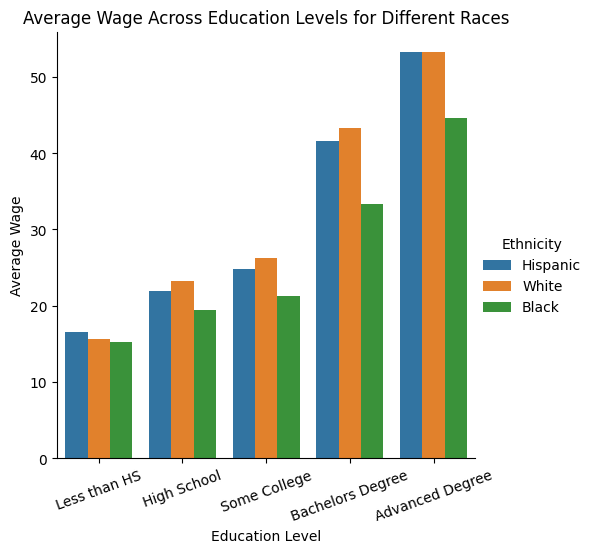

```python
# Create a new dataframe for the average wages of different groups
average_wages = pd.DataFrame({
    'Education Level': ['Less than HS', 'High School', 'Some College', 'Bachelors Degree', 'Advanced Degree'],
    'Hispanic': [16.52, 21.94, 24.81, 41.6, 53.22],
    'White': [15.7, 23.31, 26.28, 43.3, 53.3],
    'Black': [15.19, 19.39, 21.34, 33.39, 44.67]
})

# Melt the data to long format
melted_wages = average_wages.melt(id_vars='Education Level', var_name='Ethnicity', value_name='Average Wage')

# Create the categorical plot
plt.figure(figsize=(10, 6))
plot = sns.catplot(x='Education Level', y='Average Wage', hue='Ethnicity', data=melted_wages, kind='bar')
plot.set_axis_labels('Education Level', 'Average Wage')
plt.title('Average Wage Across Education Levels for Different Races')
plt.xticks(rotation=20)
plt.show()
```

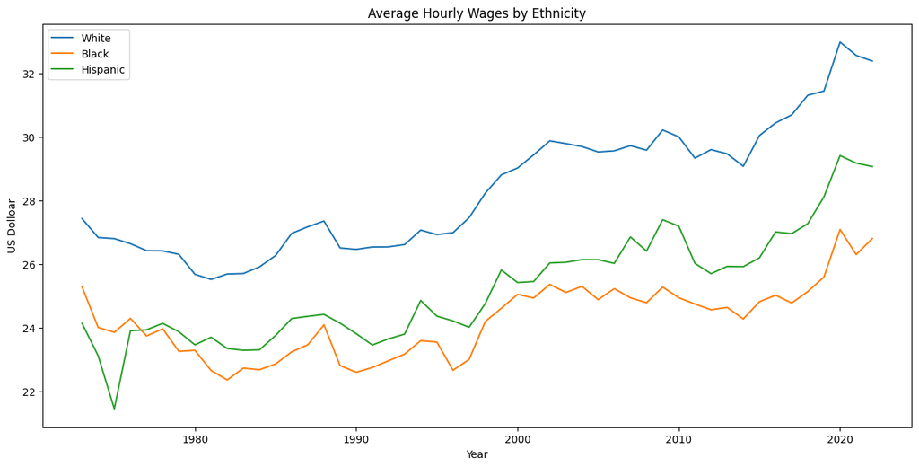

```python
plt.figure(figsize=(15, 7))
plt.plot(df_wag.year, df_wag.white, label='White')
plt.plot(df_wag.year, df_wag.black, label='Black')
plt.plot(df_wag.year, df_wag.hispanic, label='Hispanic')
plt.title('Average Hourly Wages by Ethnicity')
plt.xlabel('Year')
plt.ylabel('US Dolloar')
plt.legend(loc=2)
plt.show()
```

During the last 3 decades white people have consistently recieved higher wages in comparison to black people and hispanic people.

```python
dft = df_wag.set_index('year').T
dft
```

| year | 2022 | 2021 | 2020 | 2019 | 2018 | 2017 | 2016 | 2015 | 2014 | 2013 | ... | 1982 | 1981 | 1980 | 1979 | 1978 | 1977 | 1976 | 1975 | 1974 | 1973 |
| --- | --- | --- | --- | --- | --- | --- | --- | --- | --- | --- | --- | --- | --- | --- | --- | --- | --- | --- | --- | --- | --- |
| less_than_hs | 16.520 | 16.740 | 17.020 | 16.110 | 15.940 | 15.920 | 15.450 | 15.250 | 14.660 | 14.62 | ... | 16.730 | 17.070 | 17.420 | 17.950 | 17.290 | 17.590 | 17.520 | 17.300 | 17.680 | 18.060 |
| high_school | 21.940 | 22.280 | 22.700 | 21.640 | 21.500 | 21.260 | 21.000 | 20.810 | 20.340 | 20.31 | ... | 20.650 | 20.680 | 20.900 | 21.620 | 21.520 | 21.500 | 21.760 | 21.550 | 21.600 | 22.220 |
| some_college | 24.810 | 24.920 | 25.440 | 24.000 | 23.700 | 23.310 | 23.350 | 23.170 | 22.480 | 22.50 | ... | 22.430 | 22.470 | 22.730 | 23.200 | 23.250 | 22.970 | 23.490 | 23.300 | 23.320 | 24.080 |
| bachelors_degree | 41.600 | 41.320 | 41.650 | 39.610 | 38.870 | 38.650 | 38.730 | 37.960 | 36.470 | 37.00 | ... | 30.550 | 30.170 | 30.040 | 30.570 | 30.900 | 31.070 | 31.460 | 31.450 | 31.690 | 32.800 |
| advanced_degree | 53.220 | 53.450 | 53.740 | 51.570 | 51.030 | 49.400 | 49.640 | 48.420 | 47.270 | 48.54 | ... | 36.080 | 35.320 | 35.530 | 36.190 | 37.560 | 37.360 | 37.500 | 38.410 | 38.370 | 38.160 |
| ... | ... | ... | ... | ... | ... | ... | ... | ... | ... | ... | ... | ... | ... | ... | ... | ... | ... | ... | ... | ... | ... |
| women | 26.750 | 27.114 | 27.510 | 26.310 | 25.796 | 25.658 | 25.432 | 25.076 | 24.556 | 24.68 | ... | 20.018 | 19.832 | 19.862 | 20.164 | 20.336 | 20.384 | 20.782 | 20.788 | 20.550 | 21.300 |
| all | 31.630 | 31.758 | 32.080 | 30.575 | 30.171 | 29.657 | 29.579 | 29.072 | 28.186 | 28.53 | ... | 24.604 | 24.401 | 24.536 | 25.002 | 25.170 | 25.167 | 25.424 | 25.396 | 25.397 | 26.003 |
| white | 32.378 | 32.554 | 32.974 | 31.434 | 31.302 | 30.684 | 30.432 | 30.034 | 29.068 | 29.46 | ... | 25.680 | 25.510 | 25.670 | 26.300 | 26.408 | 26.416 | 26.634 | 26.794 | 26.828 | 27.422 |
| black | 26.796 | 26.292 | 27.080 | 25.584 | 25.130 | 24.768 | 25.014 | 24.808 | 24.266 | 24.63 | ... | 22.348 | 22.646 | 23.280 | 23.248 | 23.958 | 23.732 | 24.284 | 23.848 | 23.998 | 25.276 |
| hispanic | 29.060 | 29.166 | 29.404 | 28.108 | 27.266 | 26.950 | 27.004 | 26.190 | 25.912 | 25.92 | ... | 23.338 | 23.692 | 23.452 | 23.866 | 24.128 | 23.926 | 23.896 | 21.442 | 23.108 | 24.128 |

66 rows × 50 columns

```python
dft_ed=dft.loc['less_than_hs':'advanced_degree']
dft
```

| year | 2022 | 2021 | 2020 | 2019 | 2018 | 2017 | 2016 | 2015 | 2014 | 2013 | ... | 1982 | 1981 | 1980 | 1979 | 1978 | 1977 | 1976 | 1975 | 1974 | 1973 |
| --- | --- | --- | --- | --- | --- | --- | --- | --- | --- | --- | --- | --- | --- | --- | --- | --- | --- | --- | --- | --- | --- |
| less_than_hs | 16.520 | 16.740 | 17.020 | 16.110 | 15.940 | 15.920 | 15.450 | 15.250 | 14.660 | 14.62 | ... | 16.730 | 17.070 | 17.420 | 17.950 | 17.290 | 17.590 | 17.520 | 17.300 | 17.680 | 18.060 |
| high_school | 21.940 | 22.280 | 22.700 | 21.640 | 21.500 | 21.260 | 21.000 | 20.810 | 20.340 | 20.31 | ... | 20.650 | 20.680 | 20.900 | 21.620 | 21.520 | 21.500 | 21.760 | 21.550 | 21.600 | 22.220 |
| some_college | 24.810 | 24.920 | 25.440 | 24.000 | 23.700 | 23.310 | 23.350 | 23.170 | 22.480 | 22.50 | ... | 22.430 | 22.470 | 22.730 | 23.200 | 23.250 | 22.970 | 23.490 | 23.300 | 23.320 | 24.080 |
| bachelors_degree | 41.600 | 41.320 | 41.650 | 39.610 | 38.870 | 38.650 | 38.730 | 37.960 | 36.470 | 37.00 | ... | 30.550 | 30.170 | 30.040 | 30.570 | 30.900 | 31.070 | 31.460 | 31.450 | 31.690 | 32.800 |
| advanced_degree | 53.220 | 53.450 | 53.740 | 51.570 | 51.030 | 49.400 | 49.640 | 48.420 | 47.270 | 48.54 | ... | 36.080 | 35.320 | 35.530 | 36.190 | 37.560 | 37.360 | 37.500 | 38.410 | 38.370 | 38.160 |
| ... | ... | ... | ... | ... | ... | ... | ... | ... | ... | ... | ... | ... | ... | ... | ... | ... | ... | ... | ... | ... | ... |
| women | 26.750 | 27.114 | 27.510 | 26.310 | 25.796 | 25.658 | 25.432 | 25.076 | 24.556 | 24.68 | ... | 20.018 | 19.832 | 19.862 | 20.164 | 20.336 | 20.384 | 20.782 | 20.788 | 20.550 | 21.300 |
| all | 31.630 | 31.758 | 32.080 | 30.575 | 30.171 | 29.657 | 29.579 | 29.072 | 28.186 | 28.53 | ... | 24.604 | 24.401 | 24.536 | 25.002 | 25.170 | 25.167 | 25.424 | 25.396 | 25.397 | 26.003 |
| white | 32.378 | 32.554 | 32.974 | 31.434 | 31.302 | 30.684 | 30.432 | 30.034 | 29.068 | 29.46 | ... | 25.680 | 25.510 | 25.670 | 26.300 | 26.408 | 26.416 | 26.634 | 26.794 | 26.828 | 27.422 |
| black | 26.796 | 26.292 | 27.080 | 25.584 | 25.130 | 24.768 | 25.014 | 24.808 | 24.266 | 24.63 | ... | 22.348 | 22.646 | 23.280 | 23.248 | 23.958 | 23.732 | 24.284 | 23.848 | 23.998 | 25.276 |
| hispanic | 29.060 | 29.166 | 29.404 | 28.108 | 27.266 | 26.950 | 27.004 | 26.190 | 25.912 | 25.92 | ... | 23.338 | 23.692 | 23.452 | 23.866 | 24.128 | 23.926 | 23.896 | 21.442 | 23.108 | 24.128 |

66 rows × 50 columns

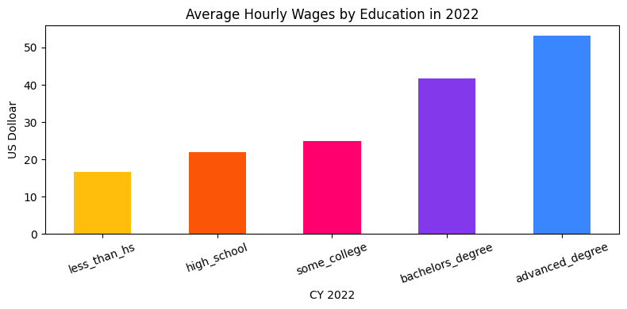

```python
plt.figure(figsize=(8, 4))
aver_wag = dft_ed[2022]
aver_wag.plot(kind='bar', color=('#ffbe0b','#fb5607','#ff006e', '#8338ec', '#3a86ff'))
plt.xticks(rotation=20)
plt.title('Average Hourly Wages by Education in 2022')
plt.xlabel('CY 2022')
plt.ylabel('US Dolloar')
plt.tight_layout()
```

The 2022 wages in the US shows that people with higher education have recieved higer wages.

```python
wag_mean = st.mean(dft_ed[2022])
wag_mean = wag_mean*40*52
wag_mean
```

```
65765.44
```

```python
sal_yr_filter = df_sal['work_year']==2022
sal_cn_filter= df_sal['company_location']=='US'
df_sal.loc[sal_yr_filter & sal_cn_filter, :]
```

|  | work_year | experience_level | employment_type | job_title | salary | salary_currency | salary_in_usd | employee_residence | remote_ratio | company_location | company_size |
| --- | --- | --- | --- | --- | --- | --- | --- | --- | --- | --- | --- |
| 2299 | 2022 | EN | FT | Machine Learning Scientist | 80000 | USD | 80000 | CA | 50 | US | S |
| 4237 | 2022 | SE | FT | Data Science Manager | 190000 | USD | 190000 | US | 100 | US | L |
| 5928 | 2022 | SE | FT | BI Developer | 130000 | USD | 130000 | US | 100 | US | L |
| 6124 | 2022 | EN | PT | Data Analyst | 34320 | USD | 34320 | US | 100 | US | S |
| 6171 | 2022 | SE | FT | Lead Data Scientist | 192000 | USD | 192000 | US | 100 | US | L |
| ... | ... | ... | ... | ... | ... | ... | ... | ... | ... | ... | ... |
| 8601 | 2022 | MI | FL | Data Scientist | 100000 | USD | 100000 | CA | 100 | US | M |
| 8604 | 2022 | SE | FT | Research Scientist | 144000 | USD | 144000 | US | 50 | US | L |
| 8608 | 2022 | EN | FT | Financial Data Analyst | 100000 | USD | 100000 | US | 50 | US | L |
| 8612 | 2022 | EN | FT | Data Engineer | 120000 | USD | 120000 | US | 100 | US | M |
| 8615 | 2022 | EN | FT | Computer Vision Engineer | 125000 | USD | 125000 | US | 0 | US | M |

1340 rows × 11 columns

```python
df_sal22us = df_sal.loc[sal_yr_filter & sal_cn_filter, :]
df_sal22us
```

|  | work_year | experience_level | employment_type | job_title | salary | salary_currency | salary_in_usd | employee_residence | remote_ratio | company_location | company_size |
| --- | --- | --- | --- | --- | --- | --- | --- | --- | --- | --- | --- |
| 2299 | 2022 | EN | FT | Machine Learning Scientist | 80000 | USD | 80000 | CA | 50 | US | S |
| 4237 | 2022 | SE | FT | Data Science Manager | 190000 | USD | 190000 | US | 100 | US | L |
| 5928 | 2022 | SE | FT | BI Developer | 130000 | USD | 130000 | US | 100 | US | L |
| 6124 | 2022 | EN | PT | Data Analyst | 34320 | USD | 34320 | US | 100 | US | S |
| 6171 | 2022 | SE | FT | Lead Data Scientist | 192000 | USD | 192000 | US | 100 | US | L |
| ... | ... | ... | ... | ... | ... | ... | ... | ... | ... | ... | ... |
| 8601 | 2022 | MI | FL | Data Scientist | 100000 | USD | 100000 | CA | 100 | US | M |
| 8604 | 2022 | SE | FT | Research Scientist | 144000 | USD | 144000 | US | 50 | US | L |
| 8608 | 2022 | EN | FT | Financial Data Analyst | 100000 | USD | 100000 | US | 50 | US | L |
| 8612 | 2022 | EN | FT | Data Engineer | 120000 | USD | 120000 | US | 100 | US | M |
| 8615 | 2022 | EN | FT | Computer Vision Engineer | 125000 | USD | 125000 | US | 0 | US | M |

1340 rows × 11 columns

```python
sal_mean = st.mean(df_sal22us['salary_in_usd'])
sal_mean
```

```
147559.5843283582
```

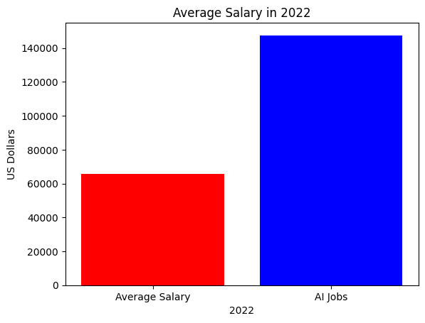

```python
x = ['Average Salary', 'AI Jobs']
y = [wag_mean, sal_mean]

plt.bar(x, y, color=('red','blue'))
plt.title("Average Salary in 2022")
plt.xlabel("2022")
plt.ylabel("US Dollars")
plt.show()
```

In 2022 people with AI related jobs in the US have recieved a salary more than twice of the average salary.

```python
df_sal_us = df_sal.loc[sal_cn_filter, :]
sal_by_year = df_sal_us.groupby('work_year').mean()
sal_by_year
```

| work_year | salary | salary_in_usd | remote_ratio |
| --- | --- | --- | --- |
| 2020 | 146912.424242 | 147167.818182 | 84.848485 |
| 2021 | 289134.595960 | 138721.505051 | 75.252525 |
| 2022 | 149400.620896 | 147559.584328 | 54.738806 |
| 2023 | 161064.405981 | 161073.276776 | 32.341947 |

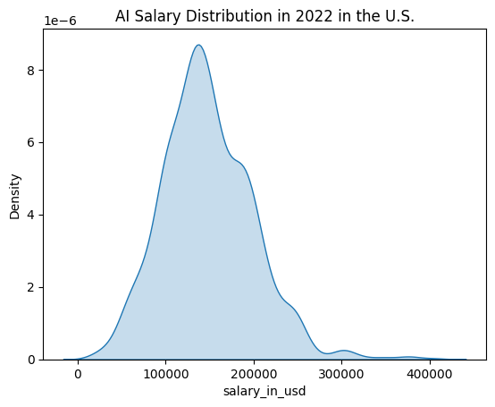

```python
sns.kdeplot(data=df_sal22us, x='salary_in_usd', common_norm=False, fill=True)
plt.title('AI Salary Distribution in 2022 in the U.S.')
plt.show()
```

The graph shows how the AI jobs salaries has been distributed in year 2022 in the US.

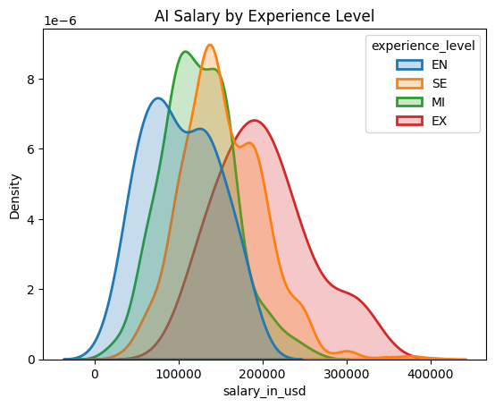

```python
sns.kdeplot(data=df_sal22us, x='salary_in_usd', hue='experience_level', common_norm=False, fill=True, linewidth=2)
plt.title('AI Salary by Experience Level')
plt.show()
```

People with higher experience recieve highers salaries.

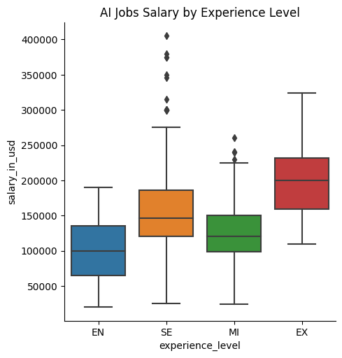

```python
sns.catplot(data=df_sal22us, x='experience_level', y='salary_in_usd', kind='box')
plt.title('AI Jobs Salary by Experience Level')
plt.show()
```

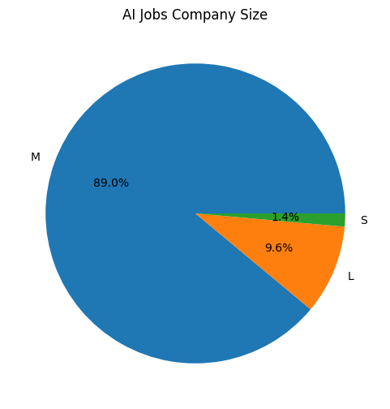

```python
names = df_sal22us['company_size'].value_counts().index.tolist()
values = df_sal22us['company_size'].value_counts().tolist()
fig = plt.figure(figsize=(6,6))
plt.pie(values, labels=names, autopct='%1.1f%%')
plt.title('AI Jobs Company Size')
plt.show()
```

89% of AI jobs are provided by medium size companies (companies with 50 to 250 employees).

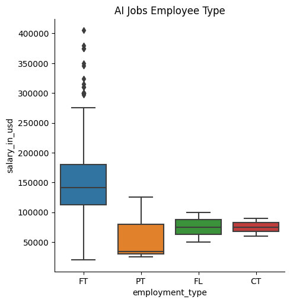

```python
sns.catplot(data=df_sal22us, x='employment_type', y='salary_in_usd', kind='box')
plt.title('AI Jobs Employee Type')
plt.show()
```

```python
!jupyter nbconvert --to html Project.ipynb
```

[output not shown]

[output cut: 133 more lines]

[output not shown]